# User-defined distributions, plus vectorization

UW 2020 short course

NIMBLE Development Team

# Original code

```r
occ_code <- nimbleCode({
  # Priors
  mean.p ~ dunif(0, 1)         # Detection intercept on prob. scale
  alpha0 <- logit(mean.p)      # Detection intercept
  alpha1 ~ dunif(-20, 20)      # Detection slope on wind
  mean.psi ~ dunif(0, 1)       # Occupancy intercept on prob. scale
  beta0 <- logit(mean.psi)     # Occupancy intercept
  beta1 ~ dunif(-20, 20)       # Occupancy slope on vegHt

  # Likelihood
  for (i in 1:M) {
    # True state model for the partially observed true state
    z[i] ~ dbern(psi[i])      # True occupancy z at site i
    logit(psi[i]) <- beta0 + beta1 * vegHt[i]
    for (j in 1:J) {
      # Observation model for the actual observations
      y[i,j] ~ dbern(p.eff[i,j])    # Detection-nondetection at i and j
      p.eff[i,j] <- z[i] * p[i,j]   # 'straw man' for WinBUGS
      logit(p[i,j]) <- alpha0 + alpha1 * wind[i,j]
    }
  }
  # Derived quantities are removed.
})
```

# Use a new distribution to marginalize over `z[i]`

```r
occ_code_marg <- nimbleCode({
  # Priors
  mean.p ~ dunif(0, 1)         # Detection intercept on prob. scale
  alpha0 <- logit(mean.p)      # Detection intercept
  alpha1 ~ dunif(-20, 20)      # Detection slope on wind
  mean.psi ~ dunif(0, 1)       # Occupancy intercept on prob. scale
  beta0 <- logit(mean.psi)     # Occupancy intercept
  beta1 ~ dunif(-20, 20)       # Occupancy slope on vegHt

  # Likelihood
  for (i in 1:M) {
    # True state model for the partially observed true state
    logit(psi[i]) <- beta0 + beta1 * vegHt[i]
    y[i, 1:J] ~ dOcc(probOcc = psi[i], probDetect = p[i, 1:J])
    for (j in 1:J) {
      logit(p[i,j]) <- alpha0 + alpha1 * wind[i,j]
    }
  }
}
)
```

# How to write a new distribution: dOcc

Prob(Detection history) = Prob(Detection history | Occupied) Prob(Occupied) + Prob(Detection history | Unoccupied) Prob(Unoccupied)

$P(y[i,1:J] | \psi, p[i, 1:J]) = \psi \prod_{j=1}^J \mbox{dbern}(y[i,j] | p[i,j]) + (1 - \psi) I_\mbox{all} (y[i, j] = 0)$

```r
dOcc <- nimbleFunction(
  run = function(x = double(1),
                 probOcc = double(0),
                 probDetect = double(1),
                 log = logical(0, default = 0)) {
    if (length(x) != length(probDetect))
      stop("Length of data does not match length of detection vector.")
    returnType(double(0))
    logProb_x_given_occupied <- sum(dbinom(x,
                                           prob = probDetect,
                                           size = 1,
                                           log = TRUE))
    prob_x_given_unoccupied <- sum(x) == 0
    prob_x <- exp(logProb_x_given_occupied) * probOcc +
      prob_x_given_unoccupied * (1 - probOcc)
    if (log)
      return(log(prob_x))
    return(prob_x)
  }
)
```

Key points:

- A `nimbleFunction` is defined by providing an R function as an argument.
- The R function has special syntax for argument types and return type.
- The `nimbleFunction` can be compiled if it is limited to basic math, distributions, for loops, if-then-else, and a few other basics.
- “compiled” means that NIMBLE will generate C++, compile that, and make it available for use from R.

# Run MCMC with the new version:

```r
occ_model_marg <- nimbleModel(occ_code_marg,
                         constants = occupancy_data,
                         inits = inits_saved)
```

```
## defining model...
```

```
## Detected y as data within 'constants'.
```

```
## Adding y as data for building model.
```

```
## building model...
```

```
## setting data and initial values...
```

```
## running calculate on model (any error reports that follow may simply
## reflect missing values in model variables) ...
```

```
## checking model sizes and dimensions...
## model building finished.
```

```r
occ_MCMC_marg <- buildMCMC(occ_model_marg)
Cocc_model_marg <- compileNimble(occ_model_marg)
```

```
## compiling... this may take a minute. Use 'showCompilerOutput = TRUE' to see C++ compilation details.
## compilation finished.
```

```r
Cocc_MCMC_marg <- compileNimble(occ_MCMC_marg, project = occ_model_marg)
```

```
## compiling... this may take a minute. Use 'showCompilerOutput = TRUE' to see C++ compilation details.
## compilation finished.
```

```r
t_marg <- system.time(samples_marg <- runMCMC(Cocc_MCMC_marg, niter = 2500,
                      nburnin = 500))
```

```
## running chain 1...
```

```
## |-------------|-------------|-------------|-------------|
## |-------------------------------------------------------|
```

```r
library(coda, warn.conflicts = FALSE)
effectiveSize(samples_marg)
```

```
##    alpha1     beta1    mean.p  mean.psi
## 209.83625 233.35461  90.94164 146.05782
```

```r
effectiveSize(samples_marg) / t_marg['elapsed']
```

```
##   alpha1    beta1   mean.p mean.psi
## 482.3822 536.4474 209.0612 335.7651
```

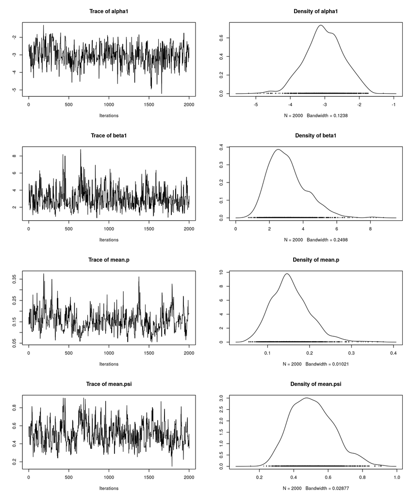

```r
plot(as.mcmc(samples_marg))
```

# Additional comments on user-defined distributions

First we write nimbleFunctions for the density and (optionally) simulation functions. Note the naming is analogous to how probability distributions are handled in R.

- The ‘d’ function should have *log* as its last argument, a binary argument for whether the log density is returned or not.
- The ‘r’ function should have *n* as its first argument but need only work for `n=1`.

The User Manual also shows how you could write CDF (‘p’) and inverse CDF (‘q’) such that you could make use of truncation with your distribution, but for standard usage all you need is the density (‘d’) and simulation (‘r’) functions (and strictly speaking you don’t need the simulation function if you won’t use any algorithms relying on that).

If you’d like to allow for different parameterizations for your distribution, and other advanced features you can `register` the distribution with NIMBLE via `registerDistributions()` but in many cases (including this one) that is not necessary. NIMBLE will just find the distribution automatically.

# Vectorizing calculations

Vectorization in NIMBLE models:

- Can make code more compact.
- Can make model and MCMC building and compiling faster.
- Can improve MCMC efficiency, but sometimes not by much.
- Can hurt MCMC efficiency if done in the wrong places.
  - Can cause additional dependencies and therefore additional calculations in MCMC steps

```r
occ_code_vec <- nimbleCode({
  # Priors
  mean.p ~ dunif(0, 1)         # Detection intercept on prob. scale
  alpha0 <- logit(mean.p)      # Detection intercept
  alpha1 ~ dunif(-20, 20)      # Detection slope on wind
  mean.psi ~ dunif(0, 1)       # Occupancy intercept on prob. scale
  beta0 <- logit(mean.psi)     # Occupancy intercept
  beta1 ~ dunif(-20, 20)       # Occupancy slope on vegHt

  # Likelihood
  logit(p[1:M,1:J]) <- alpha0 + alpha1 * wind[1:M,1:J]
  for (i in 1:M) {
    # True state model for the partially observed true state
    z[i] ~ dbern(psi[i])      # True occupancy z at site i
    logit(psi[i]) <- beta0 + beta1 * vegHt[i]
    p.eff[i, 1:J] <- z[i] * p[i, 1:J]   # 'straw man' for WinBUGS
    for (j in 1:J) {
      # Observation model for the actual observations
      y[i,j] ~ dbern(p.eff[i,j])    # Detection-nondetection at i and j
    }
  }
  # Derived quantities are removed.
}
)
```

# Run MCMC with the vectorized version:

```r
occ_mod_vec <- nimbleModel(occ_code_vec,
                         constants = occupancy_data,
                         inits = inits_saved)
```

```
## defining model...
```

```
## Detected y as data within 'constants'.
```

```
## Adding y, wind as data for building model.
```

```
## building model...
```

```
## setting data and initial values...
```

```
## running calculate on model (any error reports that follow may simply reflect missing values in model variables) ...
## checking model sizes and dimensions...
## model building finished.
```

```r
occ_MCMC_vec <- buildMCMC(occ_mod_vec)
Cocc_mod_vec <- compileNimble(occ_mod_vec)
```

```
## compiling... this may take a minute. Use 'showCompilerOutput = TRUE' to see C++ compilation details.
## compilation finished.
```

```r
Cocc_MCMC_vec <- compileNimble(occ_MCMC_vec, project = occ_mod_vec)
```

```
## compiling... this may take a minute. Use 'showCompilerOutput = TRUE' to see C++ compilation details.
## compilation finished.
```

```r
t_vec <- system.time(samples_vec <- runMCMC(Cocc_MCMC_vec, niter = 2500,
         nburnin = 500))
```

```
## running chain 1...
```

```
## |-------------|-------------|-------------|-------------|
## |-------------------------------------------------------|
```

```r
effectiveSize(samples_vec)
```

```
##    alpha1     beta1    mean.p  mean.psi
## 186.73744  79.17533  98.19774  74.22968
```

```r
effectiveSize(samples_vec) / t_vec['elapsed']
```

```
##   alpha1    beta1   mean.p mean.psi
## 526.0210 223.0291 276.6133 209.0977
```

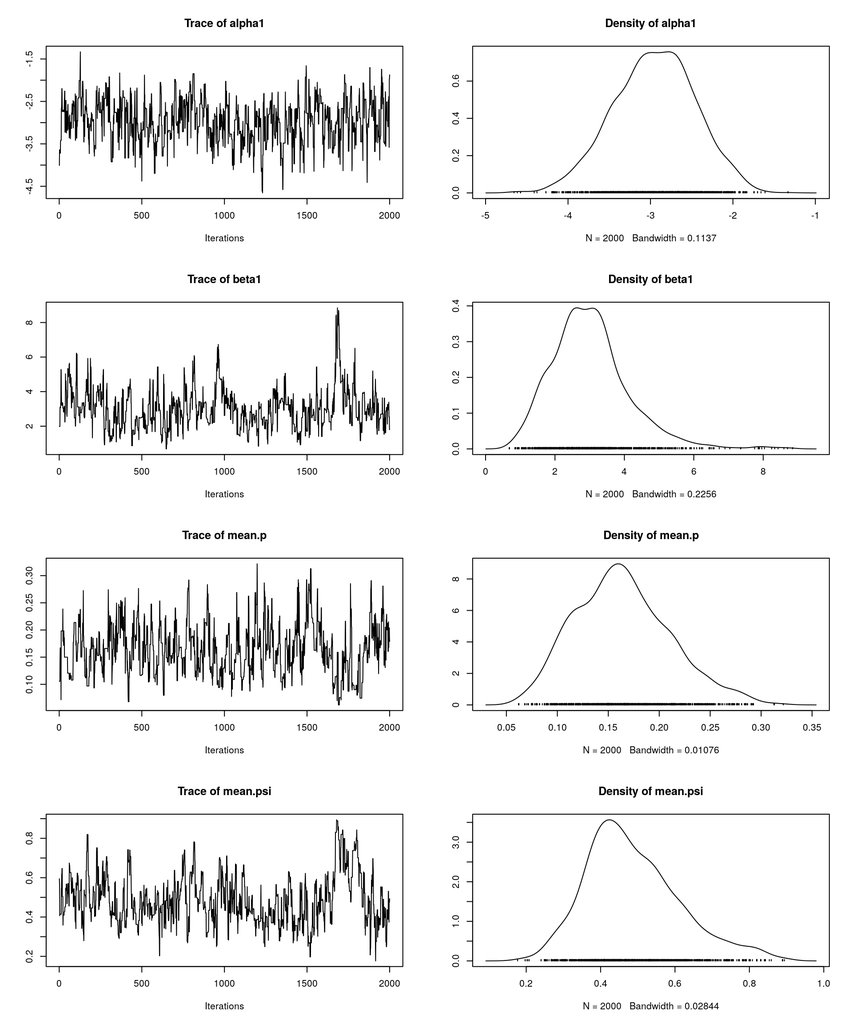

```r
plot(as.mcmc(samples_vec))
```